# Imports

```python
import yfinance as yf
import numpy as np
import pandas as pd
import matplotlib.pyplot as plt

from scipy import stats
from scipy.optimize import minimize
from scipy.stats import norm, t

import statsmodels.api as sm
from statsmodels.graphics.tsaplots import plot_acf
from statsmodels.graphics.gofplots import qqplot
```

# 1. Daily volatility forecast using MA and EWMA

**Method**

- To estimate daily volatility for the Nasdaq 100 index (2021–2024), we first collected closing prices and converted them into daily logarithmic returns.
- For moving average **(MA)** volatility:
  - Apply a 60-day rolling window.
- Iterate over returns:
  - If fewer than 60 days are available, assign `NaN`.
  - Otherwise, take the last 60 squared returns.
- Compute volatility:
  - Average the squared returns over the window.
  - Take the square root → volatility estimate.
  - Simulate the process one step at a time, iterating through the data to generate a full time series of daily volatility estimates.
- For exponentially weighted moving average **(EWMA)** volatility:
  - Choose a decay factor λ = 0.94 and a rolling window length of 60 observations.
  - Compute a scaling factor $k = \frac{1-\lambda}{\lambda(1-\lambda^{60})} $to normalize the weights.
  - For each day t, calculate volatility using the past 60 squared returns:  
    $ \sigma_t^2 = k \sum_{i=1}^{60} \lambda^i \ * r_{t-i}^2 $
  - Take the square root to obtain volatility.
  - Shift the series one step ahead so that each volatility estimate serves as a forecast for the next day.
  - Generate the EWMA series by calling the function with `lam=0.94` and `window=60`.

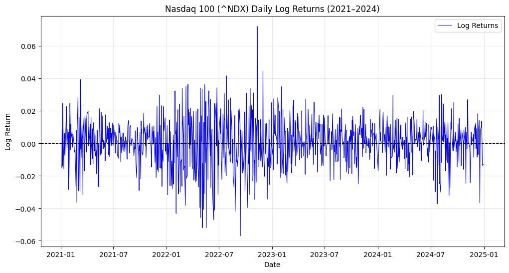

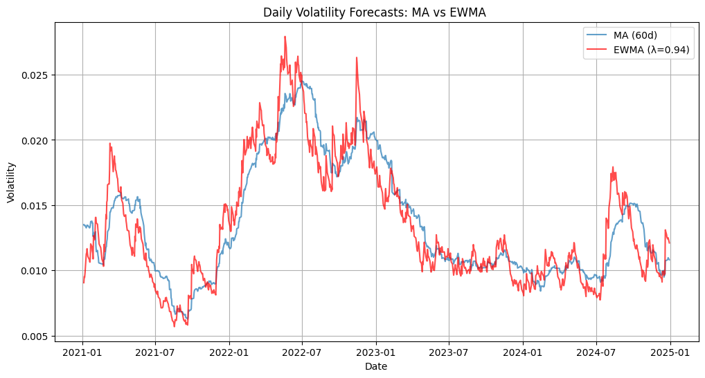

```python
forecast_data = yf.Ticker("^NDX").history(start="2020-10-06", end="2024-12-31")
forecast_log = np.log(forecast_data["Close"] / forecast_data["Close"].shift(1)).dropna()

# Moving Average volatility
window = 60
ma_vol = []
for i in range(len(forecast_log)):
    if i < window:
        ma_vol.append(np.nan)
    else:
        sq = forecast_log.iloc[i-window:i]**2
        ma_vol.append(np.sqrt(sq.mean()))
ma_vol = pd.Series(ma_vol, index=forecast_log.index).shift(1)

#EWMA
def ewma_volatility(returns, lam = 0.94, window = 60):
    r = returns.values
    n = len(r)
    k = (1 - lam) / (lam * (1 - lam**window))
    vol = np.full(n, np.nan)

    for t in range(window, n):
        s = 0.0

        for i in range(1, window + 1):
            s = s + (lam**i) * (r[t-i]**2)
        vol[t] = np.sqrt(k * s)

    return pd.Series(vol, index=returns.index).shift(1)

ewma94 = ewma_volatility(forecast_log, lam=0.94, window=60)

dates = "2021-01-01:2024-12-31"
s, e = dates.split(":")

# Plot
plt.figure(figsize=(12,6))
plt.plot(forecast_log[s:e], label="Log Returns", color="blue", linewidth=0.8)
plt.axhline(0, color="black", linestyle="--", linewidth=1)
plt.title("Nasdaq 100 (^NDX) Daily Log Returns (2021–2024)")
plt.xlabel("Date")
plt.ylabel("Log Return")
plt.legend()
plt.grid(True, alpha=0.3)
plt.show()

plt.figure(figsize=(12,6))
plt.plot(ma_vol, label="MA (60d)", alpha=0.7)
plt.plot(ewma94, label="EWMA (λ=0.94)", alpha=0.7, color="red")
plt.title("Daily Volatility Forecasts: MA vs EWMA ")
plt.xlabel("Date")
plt.ylabel("Volatility")
plt.legend()
plt.grid(True)
plt.show()
```

## Discussion: What is the main reason for the differences in these two forecasts?

The main difference between MA and EWMA lies in how they weigh past returns. MA assigns equal weight to all returns within its window, producing smooth but slow-reacting forecasts. EWMA, on the other hand, gives more weight to recent returns through exponential decay, making it more responsive to sudden changes in volatility. This responsiveness makes EWMA generally better for forecasting, as markets often experience rapid volatility spikes that require timely adjustments. In contrast, MA can underestimate risk during such periods, attributing current volatility to outdated shocks and potentially delaying risk management or trading decisions.

# 2. Daily volatility forecast using GARCH

**Method**

- To forecast daily volatility using GARCH(1,1), we first collected Nasdaq 100 closing prices for the calibration period 2011–2020 and converted them into daily logarithmic returns.
- For GARCH(1,1) modeling and estimation:
  - We specify the variance dynamics, where current variance depends on a constant term, the previous day’s squared return, and the previous day’s variance.
    - Recursion:  
      $ \sigma_t^2 = \omega + \alpha r_{t-1}^2 + \beta \sigma_{t-1}^2 $
  - Initialize the model using the last variance value of the calibration data.
  - Define the negative log-likelihood under the assumption of normally distributed errors.
  - Estimate the parameters (ω, α, β) by minimizing the negative log-likelihood using an optimization routine.
  - Provide an initial guess for the parameters and enforce bounds to ensure positivity and stationarity.
- For conditional variance forecasting:
  - Apply the fitted GARCH recursion `params_est` to the forecast period (2021–2024), iterating one step at a time.
  - Take the square root of the conditional variance to obtain daily volatility forecasts.

**Comparison**: Plot the GARCH volatility together with the previously computed MA (60-day) and EWMA (λ=0.94) volatilities for visual comparison across the forecast period.

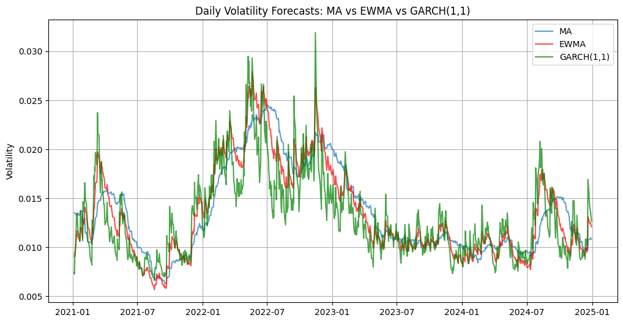

```python
# Calibration data
calibration_data = yf.Ticker("^NDX").history(start="2011-01-01", end="2020-12-31")
calibration_log = np.log(calibration_data["Close"] / calibration_data["Close"].shift(1)).dropna()


# GARCH likelihood
def garch_likelihood(params, returns):
    omega, alpha, beta = params
    T = len(returns)
    sigma2 = np.zeros(T)
    sigma2[0] = np.var(returns)
    for t in range(1, T):
        sigma2[t] = omega + alpha * returns[t-1]**2 + beta * sigma2[t-1]
    garch_likelihood.last_sigma2 = sigma2[-1]
    loglik = -0.5 * np.sum(np.log(sigma2) + returns**2 / sigma2)
    return -loglik  # minimize negative log-likelihood


# Fit GARCH(1,1)
init_params = [0.001, 0.05, 0.9]
bounds = [(1e-8, 1), (0, 1), (0, 1)]

res = minimize(garch_likelihood, init_params, args=(calibration_log.values,),
               bounds=bounds)

params_est = res.x
last_sigma2 = garch_likelihood.last_sigma2

# Conditional variance
def conditional_variance(returns, params):
    omega, alpha, beta = params
    T = len(returns)
    sigma2 = np.zeros(T)
    sigma2[0] = last_sigma2
    for t in range(1, T):
        sigma2[t] = omega + alpha * returns[t-1]**2 + beta * sigma2[t-1]
    return sigma2


dates = "2021-01-01:2024-12-31"
s, e = dates.split(":")

sigma2_test = conditional_variance(forecast_log.values, params_est)

garch_vol = pd.Series(np.sqrt(sigma2_test), index=forecast_log.index).shift(1)

# Plot
plt.figure(figsize=(12,6))
plt.plot(ma_vol[s:e], label="MA", alpha=0.7)
plt.plot(ewma94[s:e], label="EWMA", alpha=0.7, color="red")
plt.plot(garch_vol[s:e], label="GARCH(1,1)", alpha=0.7, color= "green")
plt.title("Daily Volatility Forecasts: MA vs EWMA vs GARCH(1,1)")
plt.ylabel("Volatility")
plt.legend()
plt.grid(True)
plt.show()
```

## Discussion: What is the main reason for the difference between the GARCH and the EWMA forecast

Both GARCH and EWMA are methods for forecasting market volatility, but they differ in complexity and how they take past information into account. GARCH models describe the evolution of volatility over time using three parameters (ω, α, β), allowing it to capture patterns such as volatility clustering and persistence. This flexibility enables GARCH to respond dynamically to changing market conditions.

EWMA on the other hand, relies on a single smoothing parameter, λ, which gives more weight to recent returns. It reacts quickly to new information but does not account for the day-to-day structure or persistence of volatility. As a result, while EWMA is simpler and easier to implement, it may overlook some of the patterns that GARCH can capture.

A key element in comparing GARCH and EWMA lies in how they assign weight to past returns.

- In EWMA, volatility is estimated as a weighted average of past squared returns with exponentially decaying weights. In general, as the sample length grows (T -> ∞), the formula converges to the recursive form: $ \sigma_t^2 = (1-\lambda) y_{t-1}^2 + \lambda \sigma_{t-1}^2, $ where the reaction to new shocks is given by the parameter (1 − λ).
- In GARCH(1,1), this role is captured by α, while β controls persistence from past volatility estimates.

In our results, the estimated GARCH coefficient α = 0.1448 is noticeably larger than the EWMA reaction parameter (1 − λ) = 0.06. This means that the GARCH model reacts more strongly to new market shocks than EWMA, while still incorporating persistence effects through β. The EWMA model spreads its weighting scheme across the last 60 observations with exponential decay. This means that EWMA produces a smoother, gradually adjusting volatility path, while GARCH responds more sharply to sudden jumps in volatility.

This behavior can be seen in the plot where the GARCH(1,1) volatility estimates show stronger spikes and quicker adjustments after large returns, while the EWMA line rises more steadily because of its distributed weighting structure.

# 3. GARCH model diagnostics

## a) What are the GARCH-parameters and what is the unconditional volatility?

**Method**

- We use `params_est` which are the estimated GARCH parameters (ω, α, β) from the fitted model.
- Compute the unconditional variance of returns using the formula:

  $ \text{Var}(r_t) = \frac{\omega}{1-(\alpha+\beta)} $
- Take the square root to get unconditional volatility.
- Note: This is valid only if α + β < 1 and ω, α, β >= 0.
- Display a table summarizing ω, α, β, unconditional variance and volatility.

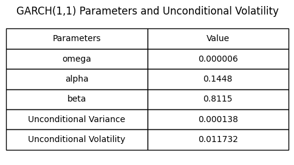

```python
omega, alpha, beta = params_est
uncond_var = omega / (1 - (alpha + beta))
uncond_vol = np.sqrt(uncond_var)

rows = ["omega", "alpha", "beta", "Unconditional Variance", "Unconditional Volatility"]
values = [f"{omega:.6f}", f"{alpha:.4f}", f"{beta:.4f}", f"{uncond_var:.6f}", f"{uncond_vol:.6f}"]

fig, ax = plt.subplots(figsize=(6, 3))
ax.axis('off')
table_data = list(zip(rows, values))
table = ax.table(cellText=table_data, colLabels=["Parameters", "Value"], loc='center', cellLoc='center')
table.scale(1, 2)
plt.title("GARCH(1,1) Parameters and Unconditional Volatility")
plt.show()
```

## b) ACF for the returns and the squared return

**Method**

Use our function called `compute_acf(data, lag)` to compute sample autocorrelations up to a chosen lag.

Returns ACF:

- Compute autocorrelations for raw returns to detect any linear correlation.
- Plot with approximate 95% confidence intervals to assess significance.

Squared-returns ACF:

- Compute autocorrelations for squared returns to detect volatility clustering.
- Plot with the same confidence intervals to highlight persistence typical in GARCH effects.

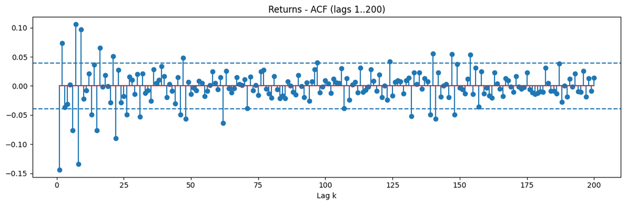

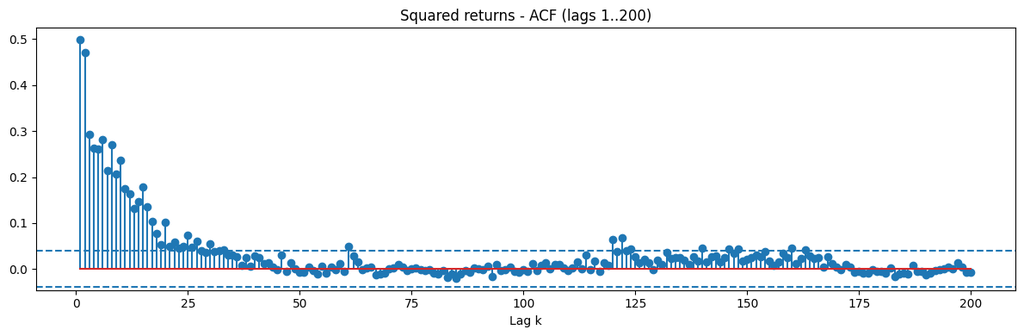

```python
def compute_acf(data, lag): #lecture2 slide 4,5,6
  y = np.asarray(data)
  T = len(y)
  y_bar = np.sum(y)/T #Mean
  difference = y - y_bar
  C0 = np.sum(difference**2) / T
  Ck = np.zeros(lag)
  for k in range(1, lag + 1):
    total = 0.0
    for t in range(0,T-k):
      total = total + (y[t] - y_bar) * (y[t+k] - y_bar)
      Ck[k-1] = total/T
  rho = Ck/C0
  return C0, Ck, rho

lag = 200
T = len(calibration_log)
C0_returns, Ck_returns, rho_returns = compute_acf(calibration_log, lag) #Returns

C0_squared_returns, Ck_squared_returns, rho_squared_returns = compute_acf(calibration_log**2, lag) #Squared returns

# Plot for returns
lags = np.arange(1, lag + 1)
ci = 1.96 / np.sqrt(T)

plt.figure(figsize=(12, 4))
plt.stem(lags, rho_returns)
plt.axhline(ci, linestyle="--")
plt.axhline(-ci, linestyle="--")
plt.title("Returns - ACF (lags 1..200)")
plt.xlabel("Lag k")
plt.tight_layout()
plt.show()

# Plot for squared returns
plt.figure(figsize=(12, 4))
plt.stem(lags, rho_squared_returns)
plt.axhline(ci, linestyle="--")
plt.axhline(-ci, linestyle="--")
plt.title("Squared returns - ACF (lags 1..200)")
plt.xlabel("Lag k")
plt.tight_layout()
plt.show()
```

## c) ACF for the residuals and the squared residuals

**Method**

- Compute the conditional variance over the calibration set using the fitted parameters and take the square root.
- Standardize residuals by dividing returns by their conditional standard deviation. Also skip the first 100 residuals to lessen the influence of the chosen value of $\sigma^2$.
- ACF of residuals: Check autocorrelations of standardized residuals by using the `compute_acf(data, lag)` function.
- ACF of squared residuals: Check autocorrelations of squared standardized residuals, also using the `compute_acf(data, lag)`.

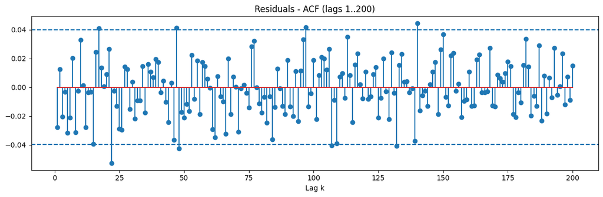

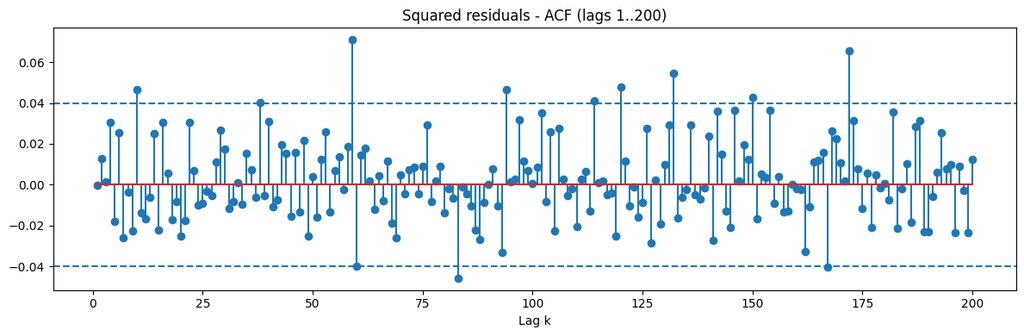

```python
# Residuals = returns divided by conditional volatility
sigma2_train = conditional_variance(calibration_log.values, params_est)
residuals = calibration_log.values / np.sqrt(sigma2_train)
residuals = residuals[100:]

# ACF residuals
C0_resid, Ck_resid, rho_resid = compute_acf(residuals, lag)

# ACF squared residuals
C0_resid_sq, Ck_resid_sq, rho_resid_sq = compute_acf(residuals**2, lag)

# Plot
lags = np.arange(1, lag + 1)
T = len(residuals)
ci = 1.96 / np.sqrt(T)

#Residuals
plt.figure(figsize=(12, 4))
plt.stem(lags, rho_resid)
plt.axhline(ci, linestyle="--")
plt.axhline(-ci, linestyle="--")
plt.title("Residuals - ACF (lags 1..200)")
plt.xlabel("Lag k")
plt.tight_layout()
plt.show()

#Squared Residuals
plt.figure(figsize=(12, 4))
plt.stem(lags, rho_resid_sq)
plt.axhline(ci, linestyle="--")
plt.axhline(-ci, linestyle="--")
plt.title("Squared residuals - ACF (lags 1..200)")
plt.xlabel("Lag k")
plt.tight_layout()
plt.show()
```

## d) Histogram of the residuals together with a normal pdf

**Method**

- Take the average of residuals as well as the standard deviation.
- Plot a histogram of the residuals.
- Plot the normal PDF based on the mean and standard deviation computed earlier.

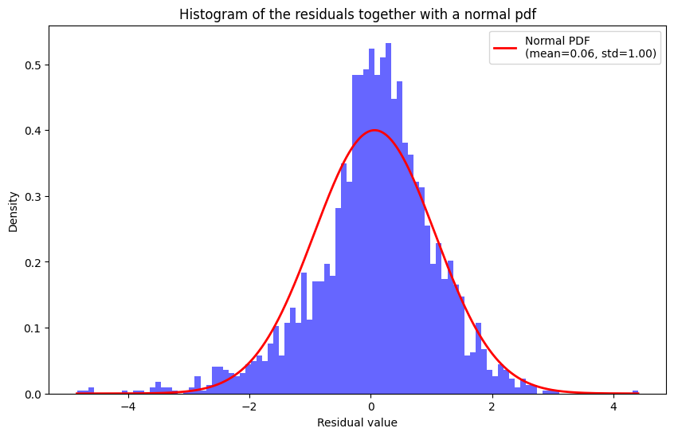

```python
mu = np.mean(residuals)
sigma = np.std(residuals)

# Histogram of residuals
plt.figure(figsize=(10, 6))
count, bins, ignored = plt.hist(residuals, bins=100, density=True, alpha=0.6, color='blue')
x = np.linspace(min(residuals), max(residuals), 1000)
pdf = stats.norm.pdf(x, mu, sigma)
plt.plot(x, pdf, 'r-', linewidth=2, label=f"Normal PDF\n(mean={mu:.2f}, std={sigma:.2f})")
plt.title("Histogram of the residuals together with a normal pdf")
plt.xlabel("Residual value")
plt.ylabel("Density")
plt.legend()
plt.show()
```

## e) QQ-plot the residuals against normal- and student t quantiles

**Method**

- Plot 4 different QQ-plots of the residuals against the normal and student t quantiles with different values of degrees of freedom (6, 7 and 8).

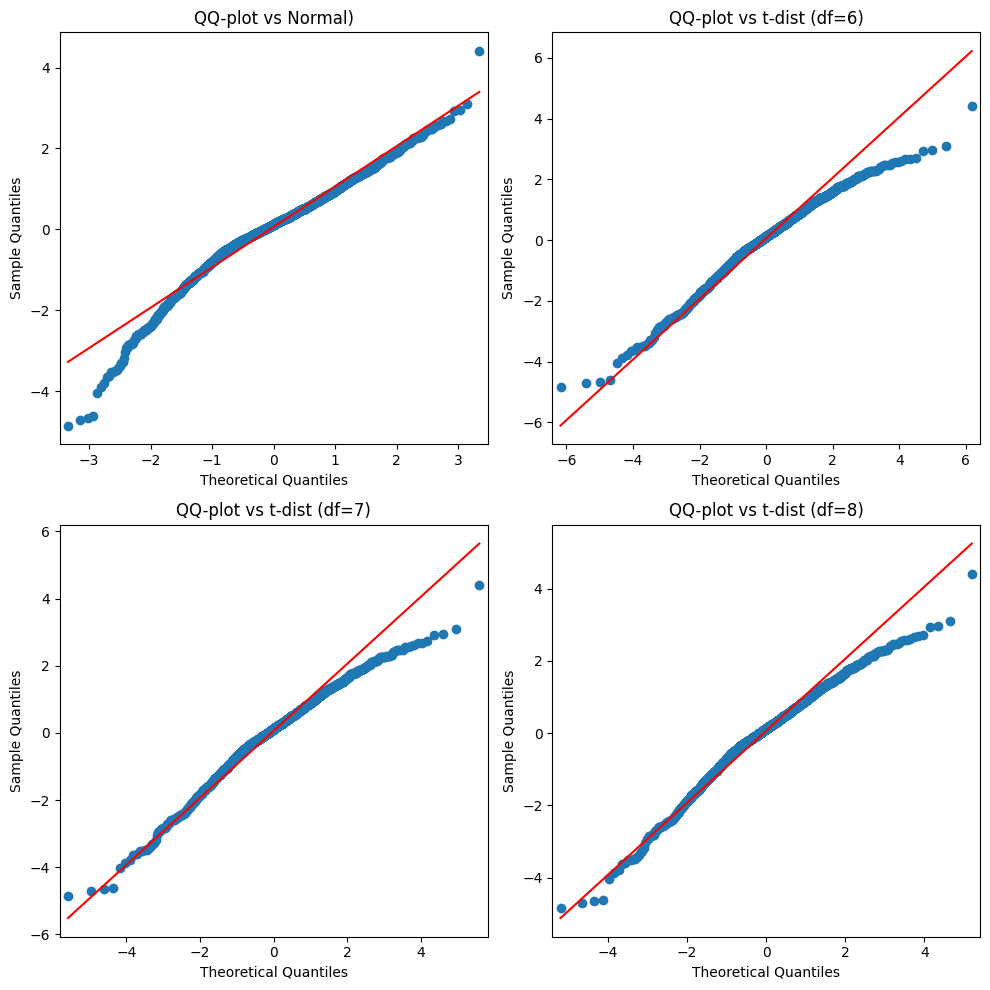

```python
fig, axes = plt.subplots(2, 2, figsize=(10, 10))

# Top-left
qqplot(residuals, stats.norm,line='s', ax=axes[0, 0])
axes[0, 0].set_title("QQ-plot vs Normal)")

# Top-right
qqplot(residuals, stats.t, distargs=(6,), loc=0, scale=1, line='s', ax=axes[0, 1])
axes[0, 1].set_title("QQ-plot vs t-dist (df=6)")

# Bottom-left
qqplot(residuals, stats.t, distargs=(7,), loc=0, scale=1, line='s', ax=axes[1, 0])
axes[1, 0].set_title("QQ-plot vs t-dist (df=7)")

# Bottom-right
qqplot(residuals, stats.t, distargs=(8,), loc=0, scale=1, line='s', ax=axes[1, 1])
axes[1, 1].set_title("QQ-plot vs t-dist (df=8)")
plt.tight_layout()
plt.show()
```

## Discussion: What does b) and c) tell you? What does d) and e) tell you?

**d) and e):**

- The histogram of GARCH residuals does not perfectly follow a normal distribution: the peak is higher than a normal curve and the left tail shows some deviation. This suggests that the normal distribution may not fully capture the residuals behavior.
- QQ-plots confirm this observation. The residuals deviate from normality particularly in the tails, while the student-t distribution appears to provide a better fit.

Overall, these results indicate that the GARCH model effectively captures the volatility dynamics, but a t-distribution may be more appropriate for modeling the residual distribution, especially to account for heavy tails. The t-distribution with a degrees of freedom of 7 seems to be the most appropriate in our opinion.

# 4. VaR forecasts using historical simulation

## a) Plot the VaR-forecasts in the same plot as the (negative) returns

**Method**

- Collect historical daily closing prices for the Nasdaq 100 Index.
- Convert prices into logarithmic returns to represent percentage changes accurately.
- Multiply returns by −1 so that losses are positive.

VaR Calculation: Rolling Historical Simulation

- Function `one_period_var(returns, window, conf)`:
  - For each day `t` with at least `window` observations, take the last `window` **loss** observations.
  - Compute the empirical **quantile** at confidence `conf=0.98`.
  - Result is a **one-step-ahead VaR** series (only defined after the first `window` days).
- Compare two window sizes: 500 days and 1000 days.

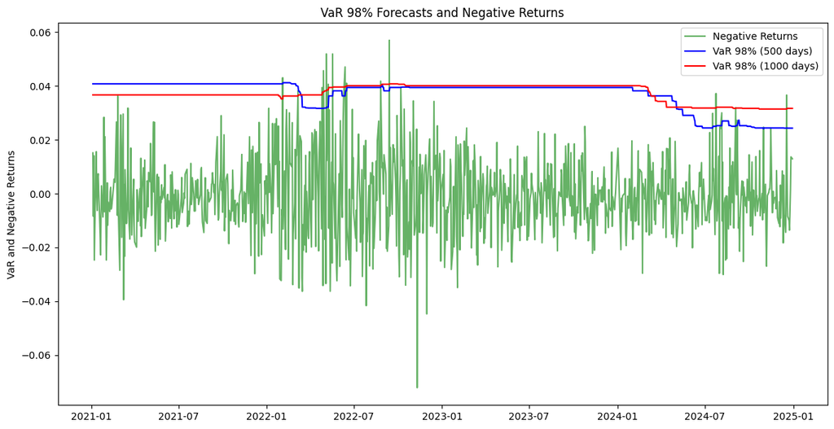

```python
data = yf.Ticker("^NDX").history(start="2017-01-01", end="2024-12-31")
log_returns = np.log(data["Close"] / data["Close"].shift(1)).dropna() * -1  # losses = positive

# Compute rolling HS VaR
def one_period_var(returns, window, conf=0.98):
    var_values = [np.nan] * len(returns)
    for t in range(window, len(returns)):
        window_data = returns.iloc[t-window:t]
        var_values[t] = np.quantile(window_data, conf)
    return pd.Series(var_values, index=returns.index)

var_500 = one_period_var(log_returns, 500, conf=0.98)
var_1000 = one_period_var(log_returns, 1000, conf=0.98)
start, end = "2021-01-01", "2024-12-31"

plt.figure(figsize=(14, 7))
plt.plot(log_returns[start:end], label="Negative Returns", color="green", alpha=0.6)
plt.plot(var_500[start:end], label="VaR 98% (500 days)", color="blue")
plt.plot(var_1000[start:end], label="VaR 98% (1000 days)", color="red")
plt.ylabel("VaR and Negative Returns")
plt.title("VaR 98% Forecasts and Negative Returns")
plt.legend()
plt.show()
```

## b) Violation ratios and number of violations for the different methods

**Method**

- Restrict the analysis to the forecast period: 2021–2024.
- Count violations: Identify days when the observed loss exceeds the forecasted VaR for each rolling window (e.g., 500-day and 1000-day).
- Compute the violation ratio (VR) to assess the accuracy of the VaR forecasts:

$$ \text{VR} = \frac{\text{Number of Violations}}{(1 - \text{confidence level}) \cdot n} $$

- With a 98% confidence level, the expected exceedance rate is 2%.

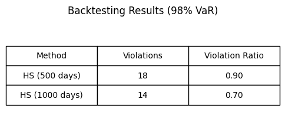

```python
n = len(log_returns[start:end])
viol_500 = sum(log_returns[start:end] > var_500[start:end])
viol_1000 = sum(log_returns[start:end] > var_1000[start:end])

# Violation ratios
vr_500 = viol_500 / (0.02 * n)
vr_1000 = viol_1000 / (0.02 * n)

# Table for plotting
rows = ["HS (500 days)", "HS (1000 days)"]
violations = [viol_500, viol_1000]
ratios = [f"{vr_500:.2f}", f"{vr_1000:.2f}"]

table_data = list(zip(rows, violations, ratios))

fig, ax = plt.subplots(figsize=(6, 2.5))
ax.axis('off')
table = ax.table(cellText=table_data,
    colLabels=["Method", "Violations", "Violation Ratio"],
    loc='center',
    cellLoc='center')
table.scale(1, 2)
plt.title("Backtesting Results (98% VaR)")
plt.show()
```

## Discussion: What are the pros and cons of using these methods?

**Pros:**

- Relatively easy to compute and understand.
- The use of a rolling window ensures that outdated observations gradually drop out of the sample, allowing the model to adapt to evolving market conditions.

**Cons:**

- HS VaR does not capture losses beyond the chosen confidence level, thereby ignoring the most extreme tail events. Expected shortfall would be a nice compliment to handle the tails.
- Because it relies solely on past data, the method reacts slow to sudden market shifts and may perform poorly during periods of increased volatility.

**Results:**

- The violation ratios for the 500-day and 1000-day windows were 0.9 and 0.7, respectively. Ratios below one indicate fewer violations than expected, suggesting that the HS approach systematically overestimates risk and produces conservative VaR estimates.

# 5. VaR forecasts using GARCH and FHS

## a) VaR forecast for GARCH and FHS

**Method**

Conditional Variance Forecasts

- Initialize the test-period variance using the last in-sample value from the training set.
- Apply the GARCH(1,1) recursion to the test-period returns using the estimated parameters (ω, α, β) to generate a time series of conditional variances:
  $$ \sigma_t^2 = \omega + \alpha r_{t-1}^2 + \beta \sigma_{t-1}^2 $$

Parametric GARCH VaR (Normal assumption)

- Take the square root of the conditional variance to obtain the standard deviation path, σₜ.
- Compute the one-step-ahead 98% VaR under the assumption of normally distributed returns:
  $$ \text{VaR}_{0.98}^{\text{GARCH}}(t) = z_{0.98} \cdot \sigma_t, \quad z_{0.98} = \Phi^{-1}(0.98) $$
- Multiply returns by −1 so that losses are positive for intuitive comparison with VaR.

Filtered Historical Simulation (FHS) VaR

- Standardize the training residuals by dividing returns by their conditional volatility.
- Compute the empirical 98th percentile of the standardized losses to capture heavy tails.
- Scale this percentile by the current conditional volatility to produce a time-varying VaR estimate:
  $$ \text{VaR}_{0.98}^{\text{FHS}}(t) = z_{0.98}^{\text{emp}} \cdot \sigma_t $$

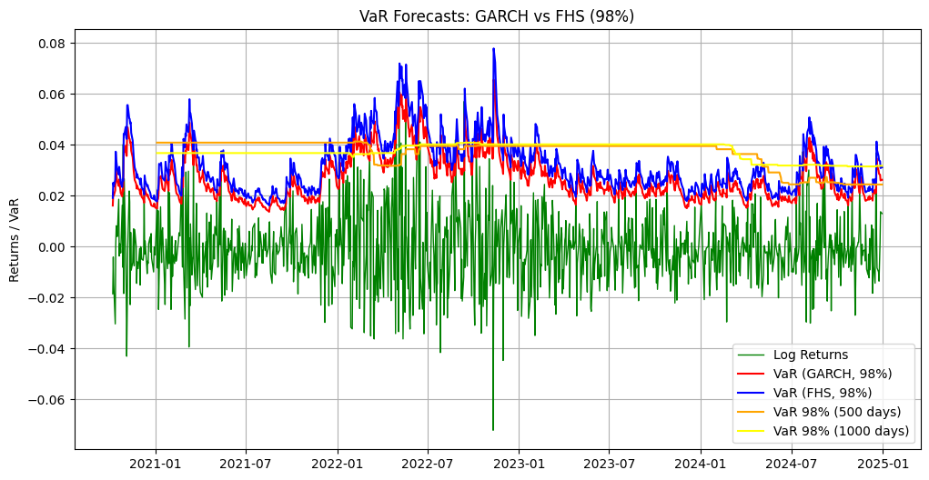

```python
sigma2_train = conditional_variance(calibration_log.values, params_est)

sigma_test = np.zeros(len(forecast_log))
sigma_test[0] = sigma2_train[-1] #initial vol

for t in range(1,len(forecast_log)):
    sigma_test[t] = res.x[0] + res.x[1] * forecast_log[t-1]**2 + res.x[2]*sigma_test[t-1]

#GARCH
VaR_GARCH = (norm.ppf(0.98) * (np.sqrt(sigma_test)))
VaR_GARCH = pd.Series(VaR_GARCH, index=forecast_log.index)

#FHS
z98 = np.quantile(-residuals, 0.98)
VaR_FHS = pd.Series(z98 * np.sqrt(sigma_test), index=forecast_log.index)

neg_ret = forecast_log * -1

# Plot actual log returns
plt.figure(figsize=(12,6))
plt.plot(neg_ret.index, neg_ret, label="Log Returns", color="green", linewidth=1)

# Plot GARCH VaR (98%)
plt.plot(VaR_GARCH.index, VaR_GARCH, label="VaR (GARCH, 98%)", color="red")

# Plot FHS VaR (98%)
VaR_FHS_series = pd.Series(VaR_FHS, index=forecast_log.index)
plt.plot(VaR_FHS_series.index, VaR_FHS_series, label="VaR (FHS, 98%)", color="blue")

plt.title("VaR Forecasts: GARCH vs FHS (98%)")
plt.ylabel("Returns / VaR")
plt.plot(var_500[start:end], label="VaR 98% (500 days)", color="orange")
plt.plot(var_1000[start:end], label="VaR 98% (1000 days)", color="yellow")
plt.legend()
plt.grid(True)
plt.show()
```

## b) Calculate the violation ratios

**Method**

- Restrict the analysis to the forecast period from 2021-01-01 to 2024-12-31.
- A violation occurs on any day where the realized return $r_t$ is less than $-\text{VaR}_t$, meaning the actual loss exceeds the forecasted VaR.
- Count the total number of violations for each model: GARCH and FHS.
- Compute the violation ratio to evaluate coverage:
  $$ \text{VR} = \frac{\text{Number of Violations}}{(1 - \text{confidence level}) \cdot n} $$
  where (n) is the number of observations and the confidence level is 0.98 (expected exceedance rate = 2%).

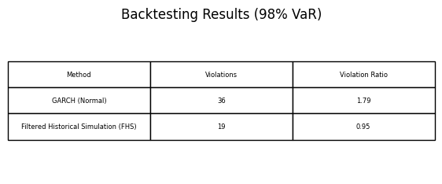

```python
# Number of observations in test sample
n = len(forecast_log[start:end])

# Count violations (returns < -VaR)
viol_GARCH = sum(forecast_log[start:end] < -VaR_GARCH[start:end])
viol_FHS = sum(forecast_log[start:end] < -VaR_FHS_series[start:end])

# Violation ratios
vr_GARCH = viol_GARCH / (0.02 * n)   # 2% expected for 98% VaR
vr_FHS = viol_FHS / (0.02 * n)

# Table for plotting
rows = ["GARCH (Normal)", "Filtered Historical Simulation (FHS)"]
violations = [viol_GARCH, viol_FHS]
ratios = [f"{vr_GARCH:.2f}", f"{vr_FHS:.2f}"]

table_data = list(zip(rows, violations, ratios))

fig, ax = plt.subplots(figsize=(7, 2.5))
ax.axis('off')
table = ax.table(
    cellText=table_data,
    colLabels=["Method", "Violations", "Violation Ratio"],
    loc='center',
    cellLoc='center'
)
table.scale(1, 2)
plt.title("Backtesting Results (98% VaR)")
plt.show()
```

## Discussion: What are the pros and cons of using these methods?

**GARCH (Normal):**  
The GARCH framework models time-varying volatility and captures clustering in financial returns, which is essential for risk forecasting. Its parametric form makes it relatively easy to estimate and interpret. However, we have used a standard GARCH model were we assume normally distributed returns, which underrepresents heavy tails and extreme events. As a result, it often underestimate risk during turbulent market periods.

**Filtered Historical Simulation (FHS):**  
Compared to the parametric approache of GARCH, FHS is better for capturing fat tails in financial data. This is because FHS builds on GARCH by scaling historical standardized residuals with the current conditional volatility.

**Comparison in General:**

- **GARCH** is convenient for its simplicity and adaptability to volatility dynamics, but its reliance on distributional assumptions limits accuracy in extreme scenarios.
- **FHS** has greater flexibility by using empirical return distributions, but requires more sufficient data. In practice, FHS often provides more realistic risk estimates in markets with fat-tailed return behavior.